# Diamond Data Analysis

Ally Weingarden, Juliet Niebylski, Ziying Peng, Leah Sun, Marisa Wong

Intermediate Deliverable for TO 414 Group Project 2

### Load Libraries

```r
library(ggplot2)
library(caret)
library(neuralnet)
library(rpart)
library(kernlab)
library(randomForest)
```

### Load in Data

```r
diamonds <- diamonds
summary(diamonds)
```

```
##      carat               cut        color        clarity          depth
##  Min.   :0.2000   Fair     : 1610   D: 6775   SI1    :13065   Min.   :43.00
##  1st Qu.:0.4000   Good     : 4906   E: 9797   VS2    :12258   1st Qu.:61.00
##  Median :0.7000   Very Good:12082   F: 9542   SI2    : 9194   Median :61.80
##  Mean   :0.7979   Premium  :13791   G:11292   VS1    : 8171   Mean   :61.75
##  3rd Qu.:1.0400   Ideal    :21551   H: 8304   VVS2   : 5066   3rd Qu.:62.50
##  Max.   :5.0100                     I: 5422   VVS1   : 3655   Max.   :79.00
##                                     J: 2808   (Other): 2531
##      table           price             x                y
##  Min.   :43.00   Min.   :  326   Min.   : 0.000   Min.   : 0.000
##  1st Qu.:56.00   1st Qu.:  950   1st Qu.: 4.710   1st Qu.: 4.720
##  Median :57.00   Median : 2401   Median : 5.700   Median : 5.710
##  Mean   :57.46   Mean   : 3933   Mean   : 5.731   Mean   : 5.735
##  3rd Qu.:59.00   3rd Qu.: 5324   3rd Qu.: 6.540   3rd Qu.: 6.540
##  Max.   :95.00   Max.   :18823   Max.   :10.740   Max.   :58.900
##
##        z
##  Min.   : 0.000
##  1st Qu.: 2.910
##  Median : 3.530
##  Mean   : 3.539
##  3rd Qu.: 4.040
##  Max.   :31.800
##
```

```r
str(diamonds)
```

```
## tibble [53,940 × 10] (S3: tbl_df/tbl/data.frame)
##  $ carat  : num [1:53940] 0.23 0.21 0.23 0.29 0.31 0.24 0.24 0.26 0.22 0.23 ...
##  $ cut    : Ord.factor w/ 5 levels "Fair"<"Good"<..: 5 4 2 4 2 3 3 3 1 3 ...
##  $ color  : Ord.factor w/ 7 levels "D"<"E"<"F"<"G"<..: 2 2 2 6 7 7 6 5 2 5 ...
##  $ clarity: Ord.factor w/ 8 levels "I1"<"SI2"<"SI1"<..: 2 3 5 4 2 6 7 3 4 5 ...
##  $ depth  : num [1:53940] 61.5 59.8 56.9 62.4 63.3 62.8 62.3 61.9 65.1 59.4 ...
##  $ table  : num [1:53940] 55 61 65 58 58 57 57 55 61 61 ...
##  $ price  : int [1:53940] 326 326 327 334 335 336 336 337 337 338 ...
##  $ x      : num [1:53940] 3.95 3.89 4.05 4.2 4.34 3.94 3.95 4.07 3.87 4 ...
##  $ y      : num [1:53940] 3.98 3.84 4.07 4.23 4.35 3.96 3.98 4.11 3.78 4.05 ...
##  $ z      : num [1:53940] 2.43 2.31 2.31 2.63 2.75 2.48 2.47 2.53 2.49 2.39 ...
```

```r
nrow(diamonds)
```

```
## [1] 53940
```

Data is from the ggplot2 library in R.

For the second group project, we have chosen a dataset on diamonds. This dataset has 10 variables which includes the price as well as various characteristics about diamonds. There are 53940 observations of data in this dataset. Our business question is: how should we price diamonds based on certain characteristics? We will answer this question by creating models to predict the price using a variety of characteristics about diamonds. This addresses the business problem of setting prices for a seller’s inventory of diamonds since it is important to set reasonable prices based on what other similar diamonds are selling for.

### Clean Data

```r
# Make certain variables to be a factor
# cut, color, clarity
diamonds$cut <- factor(diamonds$cut, ordered = FALSE)
diamonds$color <- factor(diamonds$color, ordered = FALSE)
diamonds$clarity <- factor(diamonds$clarity, ordered = FALSE)

str(diamonds)
```

```
## tibble [53,940 × 10] (S3: tbl_df/tbl/data.frame)
##  $ carat  : num [1:53940] 0.23 0.21 0.23 0.29 0.31 0.24 0.24 0.26 0.22 0.23 ...
##  $ cut    : Factor w/ 5 levels "Fair","Good",..: 5 4 2 4 2 3 3 3 1 3 ...
##  $ color  : Factor w/ 7 levels "D","E","F","G",..: 2 2 2 6 7 7 6 5 2 5 ...
##  $ clarity: Factor w/ 8 levels "I1","SI2","SI1",..: 2 3 5 4 2 6 7 3 4 5 ...
##  $ depth  : num [1:53940] 61.5 59.8 56.9 62.4 63.3 62.8 62.3 61.9 65.1 59.4 ...
##  $ table  : num [1:53940] 55 61 65 58 58 57 57 55 61 61 ...
##  $ price  : int [1:53940] 326 326 327 334 335 336 336 337 337 338 ...
##  $ x      : num [1:53940] 3.95 3.89 4.05 4.2 4.34 3.94 3.95 4.07 3.87 4 ...
##  $ y      : num [1:53940] 3.98 3.84 4.07 4.23 4.35 3.96 3.98 4.11 3.78 4.05 ...
##  $ z      : num [1:53940] 2.43 2.31 2.31 2.63 2.75 2.48 2.47 2.53 2.49 2.39 ...
```

```r
summary(diamonds)
```

```
##      carat               cut        color        clarity          depth
##  Min.   :0.2000   Fair     : 1610   D: 6775   SI1    :13065   Min.   :43.00
##  1st Qu.:0.4000   Good     : 4906   E: 9797   VS2    :12258   1st Qu.:61.00
##  Median :0.7000   Very Good:12082   F: 9542   SI2    : 9194   Median :61.80
##  Mean   :0.7979   Premium  :13791   G:11292   VS1    : 8171   Mean   :61.75
##  3rd Qu.:1.0400   Ideal    :21551   H: 8304   VVS2   : 5066   3rd Qu.:62.50
##  Max.   :5.0100                     I: 5422   VVS1   : 3655   Max.   :79.00
##                                     J: 2808   (Other): 2531
##      table           price             x                y
##  Min.   :43.00   Min.   :  326   Min.   : 0.000   Min.   : 0.000
##  1st Qu.:56.00   1st Qu.:  950   1st Qu.: 4.710   1st Qu.: 4.720
##  Median :57.00   Median : 2401   Median : 5.700   Median : 5.710
##  Mean   :57.46   Mean   : 3933   Mean   : 5.731   Mean   : 5.735
##  3rd Qu.:59.00   3rd Qu.: 5324   3rd Qu.: 6.540   3rd Qu.: 6.540
##  Max.   :95.00   Max.   :18823   Max.   :10.740   Max.   :58.900
##
##        z
##  Min.   : 0.000
##  1st Qu.: 2.910
##  Median : 3.530
##  Mean   : 3.539
##  3rd Qu.: 4.040
##  Max.   :31.800
##
```

Before moving to the analysis of the data set, we cleaned the data to prepare it for regression. Cut, color, and clarity were ordinal factors. We decided to change cut, color, and clarity to be factors which are not ordered.

### Regression

```r
diamonds_model <- lm(price ~ ., data = diamonds)
summary(diamonds_model)
```

```
##
## Call:
## lm(formula = price ~ ., data = diamonds)
##
## Residuals:
##      Min       1Q   Median       3Q      Max
## -21376.0   -592.4   -183.5    376.4  10694.2
##
## Coefficients:
##               Estimate Std. Error t value Pr(>|t|)
## (Intercept)   2184.477    408.197   5.352 8.76e-08 ***
## carat        11256.978     48.628 231.494  < 2e-16 ***
## cutGood        579.751     33.592  17.259  < 2e-16 ***
## cutVery Good   726.783     32.241  22.542  < 2e-16 ***
## cutPremium     762.144     32.228  23.649  < 2e-16 ***
## cutIdeal       832.912     33.407  24.932  < 2e-16 ***
## colorE        -209.118     17.893 -11.687  < 2e-16 ***
## colorF        -272.854     18.093 -15.081  < 2e-16 ***
## colorG        -482.039     17.716 -27.209  < 2e-16 ***
## colorH        -980.267     18.836 -52.043  < 2e-16 ***
## colorI       -1466.244     21.162 -69.286  < 2e-16 ***
## colorJ       -2369.398     26.131 -90.674  < 2e-16 ***
## claritySI2    2702.586     43.818  61.677  < 2e-16 ***
## claritySI1    3665.472     43.634  84.005  < 2e-16 ***
## clarityVS2    4267.224     43.853  97.306  < 2e-16 ***
## clarityVS1    4578.398     44.546 102.779  < 2e-16 ***
## clarityVVS2   4950.814     45.855 107.967  < 2e-16 ***
## clarityVVS1   5007.759     47.160 106.187  < 2e-16 ***
## clarityIF     5345.102     51.024 104.757  < 2e-16 ***
## depth          -63.806      4.535 -14.071  < 2e-16 ***
## table          -26.474      2.912  -9.092  < 2e-16 ***
## x            -1008.261     32.898 -30.648  < 2e-16 ***
## y                9.609     19.333   0.497    0.619
## z              -50.119     33.486  -1.497    0.134
## ---
## Signif. codes:  0 '***' 0.001 '**' 0.01 '*' 0.05 '.' 0.1 ' ' 1
##
## Residual standard error: 1130 on 53916 degrees of freedom
## Multiple R-squared:  0.9198, Adjusted R-squared:  0.9198
## F-statistic: 2.688e+04 on 23 and 53916 DF,  p-value: < 2.2e-16
```

We ran a linear regression model on the cleaned data with the response variable price and included all predictor variables. From doing this, we see that only variables y and z are not statistically significant at an alpha level of 0.05. All other predictor variables are statistically significant at an alpha level of 0.05 (and all of those are even statistically significant at an alpha level of 0.001). Because of having many statistically significant predictor variables at an alpha level of 0.05, we decided to go ahead and choose this dataset to use in this project to predict the price of diamonds.

### Split Data into Training and Testing Data

```r
# Get value of 70% of the data
num_training_data <- round(0.7 * nrow(diamonds))

# Get random sample of indexes for the training data
set.seed(123) # Set a seed
train_index <- sample(x = c(1:nrow(diamonds)), size = num_training_data, replace = FALSE)

# Get training data based on the train_index values randomly selected
train_diamonds <- diamonds[train_index,]
# Get testing data
test_diamonds <- diamonds[-train_index,]
# Check: make sure the number of values in training set and testing set
# add to the number of rows in the original dataset
nrow(diamonds) == nrow(train_diamonds) + nrow(test_diamonds)
```

```
## [1] TRUE
```

```r
# Get summary of training and test data, make sure similar distribution of price values
summary(train_diamonds)
```

```
##      carat               cut        color       clarity         depth
##  Min.   :0.2000   Fair     : 1130   D:4740   SI1    :9242   Min.   :43.00
##  1st Qu.:0.4000   Good     : 3408   E:6906   VS2    :8583   1st Qu.:61.00
##  Median :0.7000   Very Good: 8470   F:6654   SI2    :6417   Median :61.80
##  Mean   :0.7962   Premium  : 9704   G:7952   VS1    :5720   Mean   :61.75
##  3rd Qu.:1.0400   Ideal    :15046   H:5812   VVS2   :3504   3rd Qu.:62.50
##  Max.   :4.5000                     I:3721   VVS1   :2560   Max.   :79.00
##                                     J:1973   (Other):1732
##      table           price             x                y
##  Min.   :43.00   Min.   :  326   Min.   : 0.000   Min.   : 0.000
##  1st Qu.:56.00   1st Qu.:  947   1st Qu.: 4.710   1st Qu.: 4.720
##  Median :57.00   Median : 2398   Median : 5.690   Median : 5.710
##  Mean   :57.46   Mean   : 3918   Mean   : 5.727   Mean   : 5.731
##  3rd Qu.:59.00   3rd Qu.: 5298   3rd Qu.: 6.540   3rd Qu.: 6.530
##  Max.   :95.00   Max.   :18818   Max.   :10.230   Max.   :58.900
##
##        z
##  Min.   :0.000
##  1st Qu.:2.910
##  Median :3.520
##  Mean   :3.536
##  3rd Qu.:4.030
##  Max.   :8.060
##
```

```r
summary(test_diamonds)
```

```
##      carat              cut       color       clarity         depth
##  Min.   :0.200   Fair     : 480   D:2035   SI1    :3823   Min.   :43.00
##  1st Qu.:0.400   Good     :1498   E:2891   VS2    :3675   1st Qu.:61.00
##  Median :0.700   Very Good:3612   F:2888   SI2    :2777   Median :61.80
##  Mean   :0.802   Premium  :4087   G:3340   VS1    :2451   Mean   :61.75
##  3rd Qu.:1.050   Ideal    :6505   H:2492   VVS2   :1562   3rd Qu.:62.50
##  Max.   :5.010                    I:1701   VVS1   :1095   Max.   :79.00
##                                   J: 835   (Other): 799
##      table           price             x               y
##  Min.   :49.00   Min.   :  326   Min.   : 0.00   Min.   : 3.710
##  1st Qu.:56.00   1st Qu.:  956   1st Qu.: 4.72   1st Qu.: 4.720
##  Median :57.00   Median : 2419   Median : 5.71   Median : 5.720
##  Mean   :57.45   Mean   : 3968   Mean   : 5.74   Mean   : 5.742
##  3rd Qu.:59.00   3rd Qu.: 5387   3rd Qu.: 6.55   3rd Qu.: 6.540
##  Max.   :76.00   Max.   :18823   Max.   :10.74   Max.   :10.540
##
##        z
##  Min.   : 0.000
##  1st Qu.: 2.910
##  Median : 3.530
##  Mean   : 3.545
##  3rd Qu.: 4.040
##  Max.   :31.800
##
```

70% of the data was randomly selected to be training data, and 30% of the data is testing data.

### Linear Regression

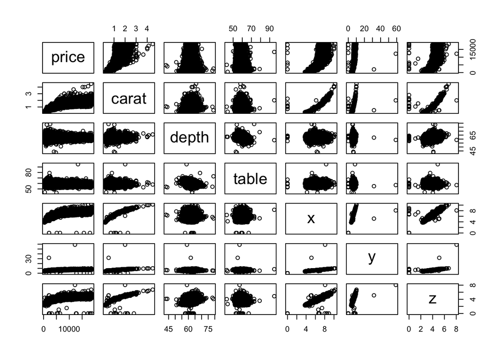

```r
plot( ~ price + carat + depth + table + x + y + z, data = train_diamonds)
```

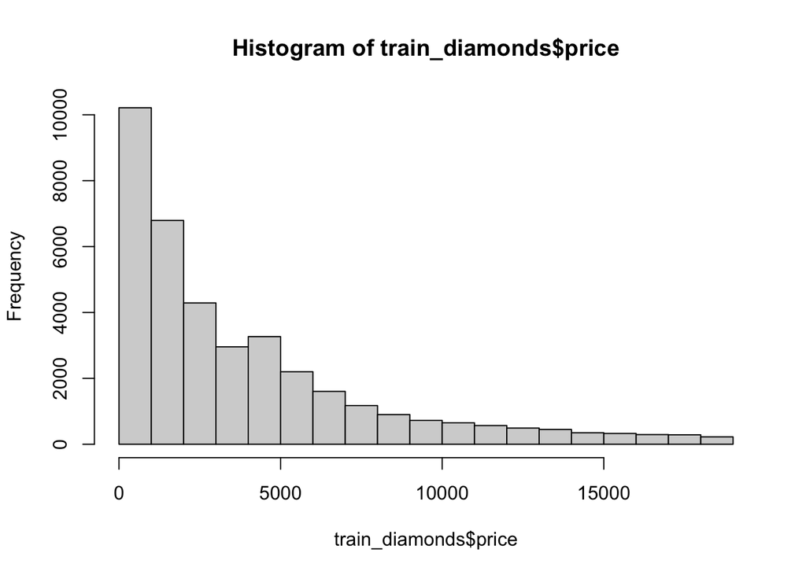

```r
#quadratic relationship between x and price

hist(train_diamonds$price)
```

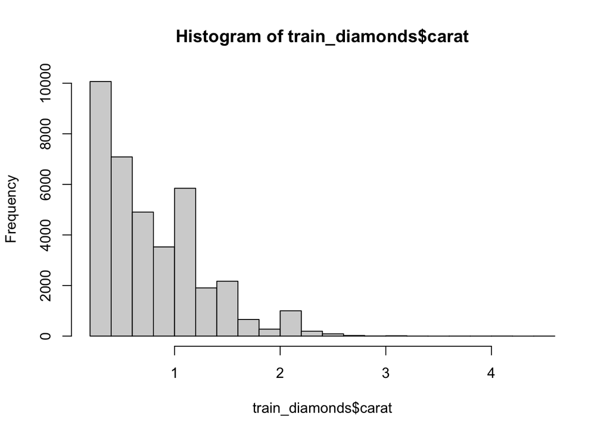

```r
hist(train_diamonds$carat)
```

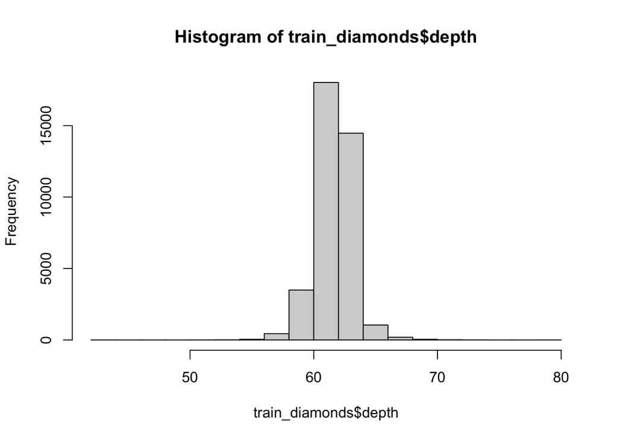

```r
hist(train_diamonds$depth)
```

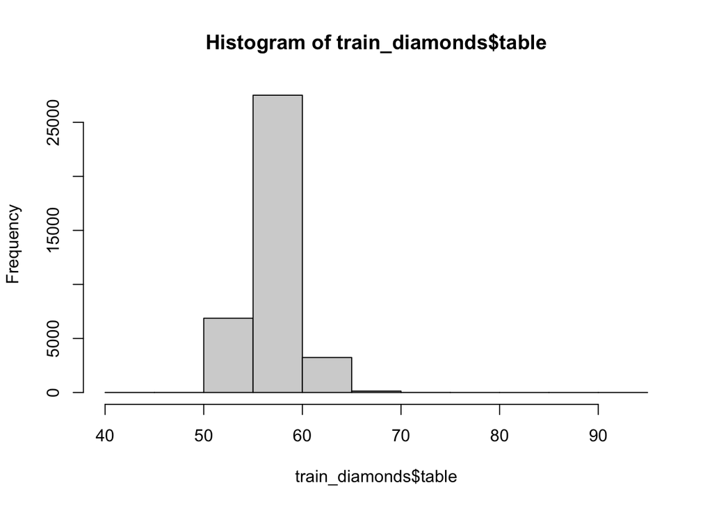

```r
hist(train_diamonds$table)
```

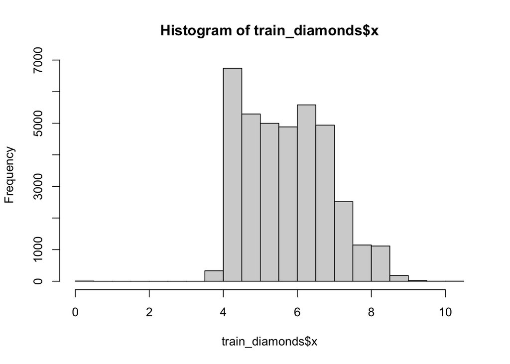

```r
hist(train_diamonds$x)
```

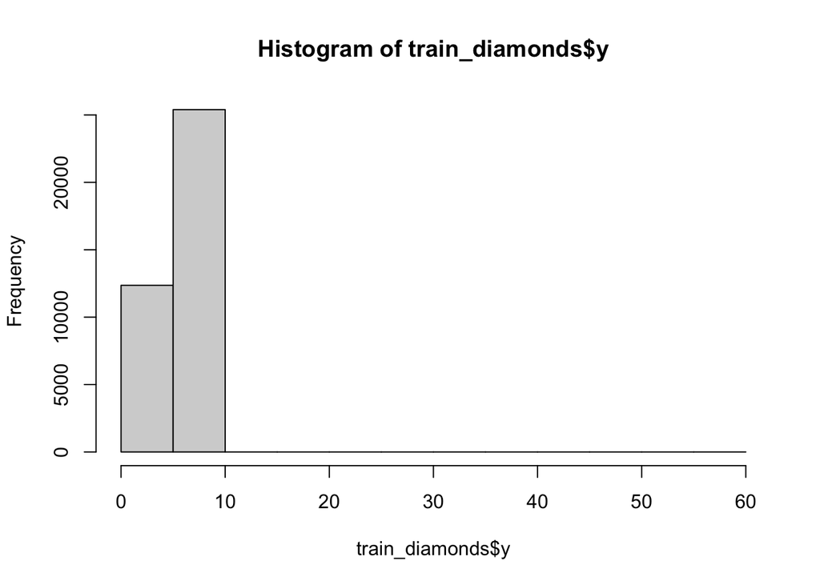

```r
hist(train_diamonds$y)
```

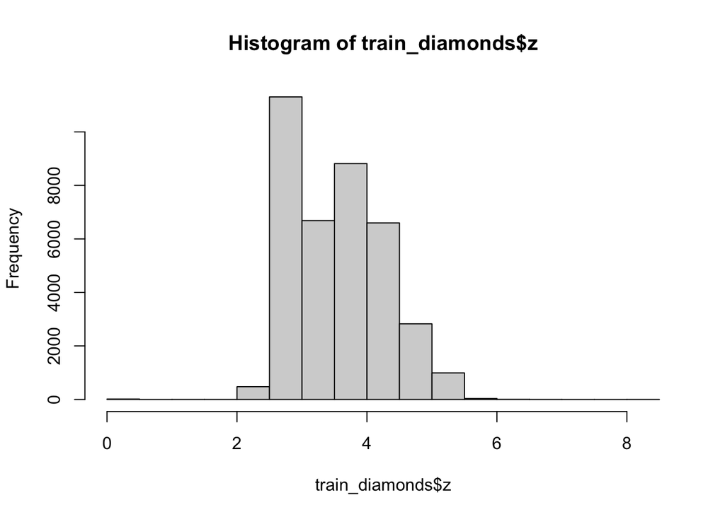

```r
hist(train_diamonds$z)
```

```r
# carat has a heavy right skew


# Main effects model
model1 <- lm(price ~ ., train_diamonds)
summary(model1)
```

```
##
## Call:
## lm(formula = price ~ ., data = train_diamonds)
##
## Residuals:
##      Min       1Q   Median       3Q      Max
## -15898.8   -585.1   -178.5    372.4  10260.6
##
## Coefficients:
##               Estimate Std. Error t value Pr(>|t|)
## (Intercept)   2098.235    541.347   3.876 0.000106 ***
## carat        11353.568     56.853 199.699  < 2e-16 ***
## cutGood        536.661     39.694  13.520  < 2e-16 ***
## cutVery Good   706.256     38.033  18.569  < 2e-16 ***
## cutPremium     737.177     37.994  19.402  < 2e-16 ***
## cutIdeal       805.329     39.449  20.415  < 2e-16 ***
## colorE        -232.102     21.098 -11.001  < 2e-16 ***
## colorF        -278.782     21.387 -13.035  < 2e-16 ***
## colorG        -488.759     20.893 -23.394  < 2e-16 ***
## colorH        -973.259     22.235 -43.772  < 2e-16 ***
## colorI       -1455.050     25.110 -57.948  < 2e-16 ***
## colorJ       -2328.454     30.800 -75.600  < 2e-16 ***
## claritySI2    2641.641     52.793  50.037  < 2e-16 ***
## claritySI1    3602.685     52.551  68.556  < 2e-16 ***
## clarityVS2    4188.867     52.811  79.317  < 2e-16 ***
## clarityVS1    4507.662     53.621  84.065  < 2e-16 ***
## clarityVVS2   4882.550     55.176  88.491  < 2e-16 ***
## clarityVVS1   4933.947     56.650  87.095  < 2e-16 ***
## clarityIF     5250.608     61.260  85.711  < 2e-16 ***
## depth          -56.256      6.666  -8.439  < 2e-16 ***
## table          -28.281      3.435  -8.234  < 2e-16 ***
## x             -954.891     52.048 -18.346  < 2e-16 ***
## y               23.908     20.019   1.194 0.232383
## z             -232.665     78.298  -2.972 0.002965 **
## ---
## Signif. codes:  0 '***' 0.001 '**' 0.01 '*' 0.05 '.' 0.1 ' ' 1
##
## Residual standard error: 1116 on 37734 degrees of freedom
## Multiple R-squared:  0.9214, Adjusted R-squared:  0.9214
## F-statistic: 1.923e+04 on 23 and 37734 DF,  p-value: < 2.2e-16
```

```r
prediction_values_lm1 <- predict(model1, test_diamonds)
summary(prediction_values_lm1)
```

```
##    Min. 1st Qu.  Median    Mean 3rd Qu.    Max.
##   -4318    1086    2818    3962    5938   39670
```

```r
postResample(prediction_values_lm1, test_diamonds$price)
```

```
##         RMSE     Rsquared          MAE
## 1162.9890409    0.9158249  744.0980344
```

```r
#       RMSE     Rsquared          MAE
# 1162.9890409    0.9158249  744.0980344

#Step Model
model2 <- step(model1, direction = "backward", trace = 0)
summary(model2)
```

```
##
## Call:
## lm(formula = price ~ carat + cut + color + clarity + depth +
##     table + x + z, data = train_diamonds)
##
## Residuals:
##      Min       1Q   Median       3Q      Max
## -15905.1   -584.9   -178.5    372.5  10259.5
##
## Coefficients:
##               Estimate Std. Error t value Pr(>|t|)
## (Intercept)   2209.753    533.236   4.144 3.42e-05 ***
## carat        11354.659     56.846 199.743  < 2e-16 ***
## cutGood        537.963     39.680  13.558  < 2e-16 ***
## cutVery Good   707.560     38.018  18.611  < 2e-16 ***
## cutPremium     737.656     37.992  19.416  < 2e-16 ***
## cutIdeal       806.219     39.442  20.441  < 2e-16 ***
## colorE        -232.026     21.098 -10.998  < 2e-16 ***
## colorF        -278.785     21.387 -13.035  < 2e-16 ***
## colorG        -488.754     20.893 -23.393  < 2e-16 ***
## colorH        -973.104     22.235 -43.765  < 2e-16 ***
## colorI       -1455.098     25.110 -57.949  < 2e-16 ***
## colorJ       -2328.550     30.800 -75.603  < 2e-16 ***
## claritySI2    2641.918     52.793  50.043  < 2e-16 ***
## claritySI1    3602.913     52.551  68.560  < 2e-16 ***
## clarityVS2    4189.075     52.811  79.321  < 2e-16 ***
## clarityVS1    4507.998     53.621  84.071  < 2e-16 ***
## clarityVVS2   4882.820     55.176  88.496  < 2e-16 ***
## clarityVVS1   4934.177     56.650  87.099  < 2e-16 ***
## clarityIF     5250.928     61.260  85.716  < 2e-16 ***
## depth          -57.982      6.508  -8.910  < 2e-16 ***
## table          -28.359      3.434  -8.258  < 2e-16 ***
## x             -947.853     51.713 -18.329  < 2e-16 ***
## z             -206.024     75.053  -2.745  0.00605 **
## ---
## Signif. codes:  0 '***' 0.001 '**' 0.01 '*' 0.05 '.' 0.1 ' ' 1
##
## Residual standard error: 1116 on 37735 degrees of freedom
## Multiple R-squared:  0.9214, Adjusted R-squared:  0.9214
## F-statistic: 2.011e+04 on 22 and 37735 DF,  p-value: < 2.2e-16
```

```r
prediction_values_lm2 <- predict(model2, test_diamonds)
summary(prediction_values_lm2)
```

```
##    Min. 1st Qu.  Median    Mean 3rd Qu.    Max.
##   -4212    1086    2818    3962    5937   39679
```

```r
postResample(prediction_values_lm2, test_diamonds$price)
```

```
##         RMSE     Rsquared          MAE
## 1162.7095378    0.9158652  744.0409995
```

```r
#just removes y
# RMSE     Rsquared          MAE
# 1162.7095378    0.9158652  744.0409995

# Interactions
model3 <- lm(price ~ clarity + color + cut + log(carat) + depth + table + x + z + clarity*cut + clarity*color + color*cut + carat*color + depth*cut + depth*color + x*depth + z*depth + I(x^2), train_diamonds)
summary(model3)
```

```
##
## Call:
## lm(formula = price ~ clarity + color + cut + log(carat) + depth +
##     table + x + z + clarity * cut + clarity * color + color *
##     cut + carat * color + depth * cut + depth * color + x * depth +
##     z * depth + I(x^2), data = train_diamonds)
##
## Residuals:
##      Min       1Q   Median       3Q      Max
## -14925.9   -439.3   -115.4    307.0   8052.7
##
## Coefficients:
##                            Estimate Std. Error t value Pr(>|t|)
## (Intercept)              -29335.394   2058.042 -14.254  < 2e-16 ***
## claritySI2                 1397.203    221.035   6.321 2.62e-10 ***
## claritySI1                 2573.612    221.748  11.606  < 2e-16 ***
## clarityVS2                 3337.321    226.602  14.728  < 2e-16 ***
## clarityVS1                 3509.557    236.783  14.822  < 2e-16 ***
## clarityVVS2                4510.670    261.558  17.245  < 2e-16 ***
## clarityVVS1                5066.856    344.161  14.722  < 2e-16 ***
## clarityIF                  6150.599    511.890  12.015  < 2e-16 ***
## colorE                     3196.528    932.436   3.428 0.000608 ***
## colorF                     2852.127    935.795   3.048 0.002307 **
## colorG                     1269.443    946.287   1.341 0.179767
## colorH                     3102.923    994.599   3.120 0.001811 **
## colorI                     1735.102   1112.199   1.560 0.118753
## colorJ                      513.316   1269.745   0.404 0.686019
## cutGood                     313.826    788.184   0.398 0.690511
## cutVery Good               3176.348    781.697   4.063 4.85e-05 ***
## cutPremium                  -97.762    817.268  -0.120 0.904784
## cutIdeal                   3596.971    924.264   3.892 9.97e-05 ***
## log(carat)                -2360.445     90.984 -25.943  < 2e-16 ***
## depth                       383.665     28.217  13.597  < 2e-16 ***
## table                        -8.729      3.170  -2.753 0.005901 **
## x                         -5895.940    847.635  -6.956 3.56e-12 ***
## z                         12283.898   1219.108  10.076  < 2e-16 ***
## carat                     10505.072    281.526  37.315  < 2e-16 ***
## I(x^2)                      206.015     21.338   9.655  < 2e-16 ***
## claritySI2:cutGood          578.441    173.934   3.326 0.000883 ***
## claritySI1:cutGood          384.862    174.173   2.210 0.027136 *
```

[output cut: 101 more lines]

```
## cutIdeal:depth              -40.273     14.395  -2.798 0.005150 **
## colorE:depth                -57.888     14.044  -4.122 3.77e-05 ***
## colorF:depth                -61.337     14.106  -4.348 1.38e-05 ***
## colorG:depth                -46.057     14.216  -3.240 0.001198 **
## colorH:depth                -61.325     14.973  -4.096 4.22e-05 ***
## colorI:depth                -34.377     16.789  -2.048 0.040610 *
## colorJ:depth                 -9.271     19.172  -0.484 0.628706
## depth:x                      67.951     12.985   5.233 1.68e-07 ***
## depth:z                    -195.888     19.951  -9.818  < 2e-16 ***
## ---
## Signif. codes:  0 '***' 0.001 '**' 0.01 '*' 0.05 '.' 0.1 ' ' 1
##
## Residual standard error: 1000 on 37621 degrees of freedom
## Multiple R-squared:  0.9371, Adjusted R-squared:  0.9369
## F-statistic:  4120 on 136 and 37621 DF,  p-value: < 2.2e-16
```

```r
prediction_values_lm3 <- predict(model3, test_diamonds)
summary(prediction_values_lm3)
```

```
##    Min. 1st Qu.  Median    Mean 3rd Qu.    Max.
##   -4683    1062    2607    3960    5913   33298
```

```r
postResample(prediction_values_lm3, test_diamonds$price)
```

```
##         RMSE     Rsquared          MAE
## 1033.2668851    0.9335579  628.8434045
```

```r
#  RMSE     Rsquared          MAE
# 1033.2668851    0.9335579  628.8434045
```